# Homework 08 – Solutions

## Question 1: Boundary and margin

Score $f(x)=0.8x_1+0.6x_2$ with $\|(0.8,0.6)\|_2=1$, so the distance from an observation to the boundary is $|f(x)|/\|\boldsymbol\beta\|=|f(x)|$. The functional margin is $y f(x)$. Classification: **beyond** if $yf(x)>1$, **on** if $yf(x)=1$, **inside** if $yf(x)<1$ (this includes misclassified points, where $yf(x)<0$).

### (a) Distances and functional margins

| Obs | x1 | x2 | y | f(x) | Distance \|f(x)\| | y·f(x) | Position | Misclassified |
| --- | --- | --- | --- | --- | --- | --- | --- | --- |
| 1 | 0.68 | 0.76 | 1 | 1.00 | 1.00 | 1.00 | on | no |
| 2 | 1.80 | -0.15 | 1 | 1.35 | 1.35 | 1.35 | beyond | no |
| 3 | 1.38 | 0.66 | 1 | 1.50 | 1.50 | 1.50 | beyond | no |
| 4 | 0.88 | 1.66 | 1 | 1.70 | 1.70 | 1.70 | beyond | no |
| 5 | 0.62 | 2.34 | 1 | 1.90 | 1.90 | 1.90 | beyond | no |
| 6 | 2.78 | -0.04 | 1 | 2.20 | 2.20 | 2.20 | beyond | no |
| 7 | 1.86 | 1.52 | 1 | 2.40 | 2.40 | 2.40 | beyond | no |
| 8 | 0.50 | 0.40 | 1 | 0.64 | 0.64 | 0.64 | inside | no |
| 9 | 0.10 | 0.20 | 1 | 0.20 | 0.20 | 0.20 | inside | no |
| 10 | -0.40 | 0.20 | 1 | -0.20 | 0.20 | -0.20 | inside | yes |
| 11 | -0.92 | -0.44 | -1 | -1.00 | 1.00 | 1.00 | on | no |
| 12 | -0.50 | -1.50 | -1 | -1.30 | 1.30 | 1.30 | beyond | no |
| 13 | -1.90 | -0.05 | -1 | -1.55 | 1.55 | 1.55 | beyond | no |
| 14 | -0.44 | -2.33 | -1 | -1.75 | 1.75 | 1.75 | beyond | no |
| 15 | -1.98 | -0.61 | -1 | -1.95 | 1.95 | 1.95 | beyond | no |
| 16 | -2.74 | 0.07 | -1 | -2.15 | 2.15 | 2.15 | beyond | no |
| 17 | -1.90 | -1.55 | -1 | -2.45 | 2.45 | 2.45 | beyond | no |
| 18 | -0.50 | -0.40 | -1 | -0.64 | 0.64 | 0.64 | inside | no |
| 19 | 0.00 | -0.40 | -1 | -0.24 | 0.24 | 0.24 | inside | no |
| 20 | 0.40 | -0.20 | -1 | 0.20 | 0.20 | -0.20 | inside | yes |

### (b) Plot

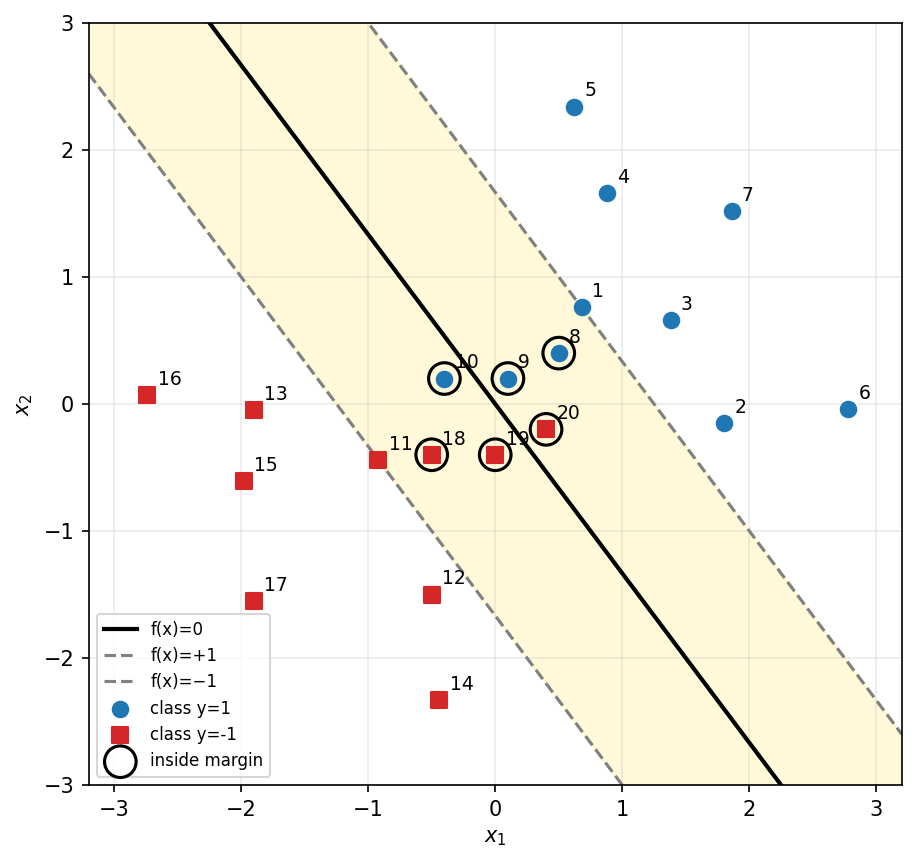

Solid black line: $f(x)=0$; dashed lines: $f(x)=\pm1$; the shaded band is the margin. Observations inside the margin are circled.

### (c) Counts and misclassifications

- **On the margin ($yf=1$):** 2 observations (1, 11).
- **Inside the margin ($yf<1$):** 6 observations (8, 9, 10, 18, 19, 20): 4 correctly classified (8, 9, 18, 19) and 2 misclassified (10, 20).
- **Beyond the margin ($yf>1$):** 12 observations (2, 3, 4, 5, 6, 7, 12, 13, 14, 15, 16, 17).

**Misclassified:** observations 10, 20, the only ones with $yf(x)<0$. Observation 10 has $y=+1$ but $f=-0.20$; observation 20 has $y=-1$ but $f=+0.20$.

## Question 2: Margin in four dimensions

$f(\mathbf x)=-1+\mathbf x^T\boldsymbol\beta$ with $\boldsymbol\beta=(1,2,-2,4)^T$, so $\|\boldsymbol\beta\|_2=\sqrt{1+4+4+16}=5$.

### (a) Projection and geometric margin

Each observation is projected onto the unit direction $\boldsymbol\beta/\|\boldsymbol\beta\|$, giving position $t=\mathbf x^T\boldsymbol\beta/5$. The boundary $f=0$ is the point $t=1/5=0.2$, and the signed distance of an observation to it is $f(\mathbf x)/5=t-0.2$.

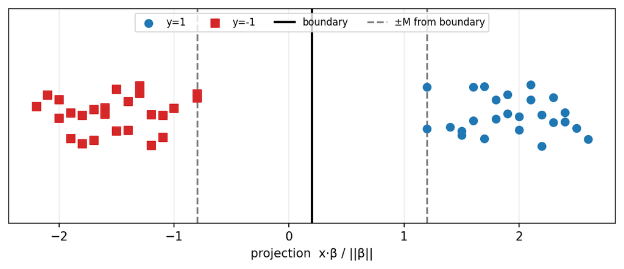

The closest observations to the boundary (sorted by $y f$):

| Obs | y | Projection t | f(x) | y·f(x) | Signed distance |
| --- | --- | --- | --- | --- | --- |
| 4 | 1 | 1.200 | 5.00 | 5.00 | +1.00 |
| 15 | -1 | -0.800 | -5.00 | 5.00 | -1.00 |
| 33 | 1 | 1.200 | 5.00 | 5.00 | +1.00 |
| 36 | -1 | -0.800 | -5.00 | 5.00 | -1.00 |
| 17 | -1 | -1.000 | -6.00 | 6.00 | -1.20 |
| 31 | 1 | 1.400 | 6.00 | 6.00 | +1.20 |

All 50 observations are on the correct side ($yf>0$ for all). Observations 4, 15, 33 and 36 are the closest, each with $yf=5$, i.e. a distance of $5/5=1$ from the boundary. The dashed lines in the plot at $t=0.2\pm1$ pass through them. Therefore

$$M=\min_i \frac{y_i f(\mathbf x_i)}{\|\boldsymbol\beta\|}=\frac{5}{5}=1.$$

### (b) SVM normalization

The smallest functional margin is $\min_i y_if(\mathbf x_i)=5$. Rescaling $(\beta_0,\boldsymbol\beta)$ by $1/5$ leaves the boundary unchanged and makes this minimum equal to 1:

$$\boldsymbol\beta_{\text{SVM}}=\tfrac15(1,2,-2,4)^T=(0.2,\,0.4,\,-0.4,\,0.8)^T,\qquad \beta_{0,\text{SVM}}=-\tfrac15=-0.2.$$

Check: the geometric margin under this normalization is $1/\|\boldsymbol\beta_{\text{SVM}}\|=1/1=1=M$, matching part (a), since $\|\boldsymbol\beta_{\text{SVM}}\|=5/5=1$.

## Question 3: Peer review of a Homework 7 skill

### (a) Analysis run

The response is `chd` (0/1), with the nine other columns used as predictors and `famhist` coded Absent = 1 and Present = 2. The data contain 462 rows and no missing values.

I chose seed 432, a stratified 70/30 split (323 training observations and 139 test observations), and 5 shared stratified cross-validation folds. I compared 12 candidates: LDA, QDA, and the average of their class probabilities, each using standardized raw predictors and PCA with 3, 5, or 7 components.

The tie rule was lowest mean cross-validation error, then fewer principal components, then LDA before averaging before QDA. The selected model was PCA7 + LDA, with mean cross-validation error 0.250. Plain LDA had mean error 0.260.

On the reserved test set, the selected model made 37 errors out of 139, for a misclassification rate of 0.266. The majority-class error was 0.345. QDA checks passed in every fold; the smallest class had 89 cases and the class covariance rank was 9 of 9.

The analysis took approximately 0.1 seconds. I did not stop the run or send a steer message.

### (b) Differences from the student’s run

These differences are seed- and design-dependent, so they are not evidence that the student made an error. They provide useful context for the review.

- **Selected model:** The student’s run selected PCA5 + QDA (CV error 0.291, test error 0.230). Mine selected PCA7 + LDA, so the skill does not produce a stable winner across runs.
- **Spread of CV errors:** My CV errors ranged from 0.250 to 0.297, while the student’s ranged from 0.291 to 0.337. In both runs, the gaps between candidates were small relative to the fold standard deviations.
- **Candidate set:** The skill allows averaging LDA and QDA probabilities. The student’s run did not use this option, while mine did.

Three improvements I recommend are:

1. **Set clear defaults:** Specify the train/test split, number of cross-validation folds, random seed, and tie-breaking rule so the results are consistent and reproducible.
2. **Show uncertainty:** Add error bars to the cross-validation performance chart to show variability and avoid overstating small differences between models.
3. **Improve report presentation:** Fix cut-off labels, remove excess blank space, and add a sentence comparing the test error with the cross-validation error.

### (c) Shared peer review

I shared my peer review in the assigned GitHub Issue: [Homework 8 Peer Review – Issue #4](https://github.com/Zhijing2023/stat432-fall2026/issues/4).